# Body mass index in adults aged 30 and over in Bharatpur, Nepal

Dataset 4: Nepal hypertension and cardiovascular risk-factor survey

RSR feasibility analysis

2026-08-03

# Introduction

This is a community-based cross-sectional survey of adults aged 30 years and over living in Bharatpur, Chitwan district, Nepal, run to estimate the prevalence of hypertension and its cardiovascular risk factors (Dhungana and colleagues, *PLOS ONE* 2016, e0185806). Height and weight were measured directly by trained enumerators rather than self-reported, and the WHO STEPS instrument supplied the behavioural and socio-economic information. Body mass index is worth analysing in its own right in this setting: Nepal is in the middle of a nutrition transition in which under- and over-nutrition coexist in the same communities, and the classical Western socio-economic gradient in adiposity (poorer people heavier) is often reversed in South Asia.

**Aim.** Among adults aged 30 and over in Bharatpur, we examined which of sex, age band, education, occupation, poverty, smoking, smokeless tobacco, alcohol, fruit and vegetable intake, salt intake, physical activity and family history of hypertension are independently associated with body mass index, mutually adjusting for the others.

This is a *Purpose 3* analysis: several predictors are of interest and the question is which remain associated with the outcome after mutual adjustment.

# Methods

**Data source.** A cross-sectional survey of 1159 adults aged 30 years and over resident in Bharatpur Municipality, Chitwan, Nepal. The source study used multistage cluster sampling: four wards were selected at random and roughly 300 participants enrolled in each, with the sample size calculation assuming a design effect of 1.5. **The ward identifier is not present in this extract** (see Limitations). Each row is one participant.

**Variables.** The outcome is `bmi`, measured body mass index in kg/m2. Predictors are sex (reference *Female*); age band in years (reference *30-39*; age was recorded only in four bands, so a per-year effect cannot be estimated); education (reference *None or informal*); main occupation (reference *Household work*); family income per head below the poverty line (reference *No*); smoking status (reference *Never*); current smokeless tobacco use (reference *No*); any alcohol in the last month (reference *No*); fruit and vegetable servings per day; estimated salt intake in g/day; physical activity level (reference *Moderate or high*); and family history of hypertension (reference *No*).

Because body mass index is the outcome here it is of course not also a predictor, and – less obviously – neither are `systolic_bp`, `diastolic_bp`, `hypertension`, `bp_awareness` or `antihypertensive_drug`. Adiposity raises blood pressure, so blood pressure is a *consequence* of the outcome; conditioning on it would be adjusting for a mediator of everything upstream and would bias every remaining coefficient. This is the mirror image of the systolic and diastolic analyses in this catalogue, where `bmi` is a legitimate predictor. Two further pairs of variables measure the same construct twice and only one of each may enter a model: `physical_activity` is a deterministic cut of `mets_min_per_week` at 600 MET-minutes per week (the “Low” group spans 0-600 and “Moderate or high” spans 620-29,260), and the categorical version is used here because it is the WHO STEPS classification the source paper reports and because the continuous version is extremely right-skewed; and `cigarettes_per_week` is zero for every never-smoker, so `smoking_status` is used instead because it also separates former from never smokers.

**Statistical analysis.** Linear regression via `lm()`, justified because the outcome is continuous. We fitted a univariable model for each predictor first, then a single multivariable model containing all of them. Predictors were chosen in advance on subject-matter grounds, not by significance. Significance threshold 0.05; estimates are reported with 95% confidence intervals. Assumptions were checked with `performance::check_model()` and `performance::check_heteroscedasticity()`. Analysis used R version 4.6.0 (2026-04-24) with tidyverse, gtsummary and performance.

**Missing data.** Complete-case analysis: 1159 of 1159 rows were analysed (0 dropped). Every variable in this file is 100% complete, so listwise deletion removes no rows at all and there is no missing-data story: no imputation, no complete-case selection bias.

# Results

## Sample characteristics

**Table 1. Sample characteristics.**

| **Characteristic** | **N** | **N = 1,159**<sup>1</sup> |
| --- | --- | --- |
| Body mass index (kg/m2) | 1,159 | 23.6 (21.0, 26.4) |
| Sex | 1,159 |  |
| Female |  | 824 (71%) |
| Male |  | 335 (29%) |
| Age band (years) | 1,159 |  |
| 30-39 |  | 383 (33%) |
| 40-49 |  | 295 (25%) |
| 50-59 |  | 218 (19%) |
| 60 or more |  | 263 (23%) |
| Education | 1,159 |  |
| None or informal |  | 626 (54%) |
| Primary |  | 136 (12%) |
| Secondary |  | 239 (21%) |
| Higher |  | 158 (14%) |
| Main occupation | 1,159 |  |
| Household work |  | 659 (57%) |
| Agriculture or labour |  | 142 (12%) |
| Job or self-employed |  | 305 (26%) |
| Unemployed |  | 53 (4.6%) |
| Below poverty line | 1,159 | 316 (27%) |
| Smoking status | 1,159 |  |
| Never |  | 770 (66%) |
| Former |  | 180 (16%) |
| Current |  | 209 (18%) |
| Smokeless tobacco use | 1,159 | 139 (12%) |
| Alcohol in the last month | 1,159 | 177 (15%) |
| Fruit and vegetable servings per day | 1,159 | 2.29 (1.43, 3.14) |
| Salt intake (g/day) | 1,159 | 2.85 (1.90, 4.55) |
| Physical activity level | 1,159 |  |
| Moderate or high |  | 744 (64%) |
| Low |  | 415 (36%) |
| Family history of hypertension | 1,159 | 170 (15%) |

<sup>1</sup> Median (Q1, Q3); n (%)

Mean body mass index was 23.8 kg/m2 (SD 4.2), with a mildly right-skewed distribution running from 13.4 to 41.7 kg/m2. Using the WHO Asian action points, 55.3% of the sample is at or above 23 kg/m2 and 17.9% at or above 27.5 kg/m2, while 9.2% are below 18.5 kg/m2 – the coexistence of under- and over-nutrition that characterises the Nepali nutrition transition. The sample is 71.1% female, a consequence of daytime household recruitment in the source survey.

## Exploratory figure

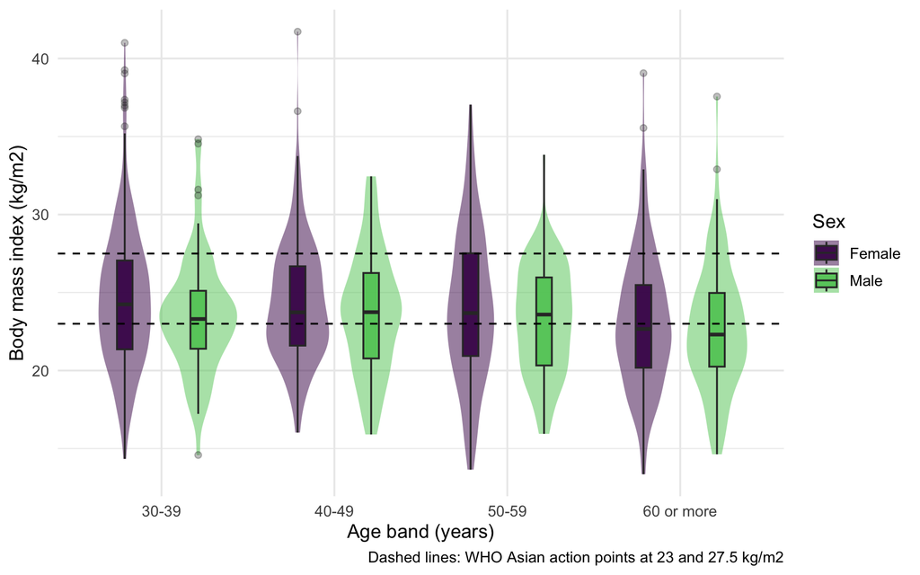

Figure 3. Body mass index by age band and sex. Dashed lines mark the WHO Asian action points of 23 and 27.5 kg/m2.

Body mass index is remarkably flat across the age bands until the oldest group, where it drops by about a kilogram per square metre in both sexes, and women sit slightly above men at every age – so unlike blood pressure, adiposity in this population is not primarily an age story.

## Univariable models

| **Characteristic** | **N** | **Beta** | **95% CI** | **p-value** |
| --- | --- | --- | --- | --- |
| Sex | 1,159 |  |  |  |
| Female |  | — | — |  |
| Male |  | -0.84 | -1.4, -0.31 | 0.002 |
| Age band (years) | 1,159 |  |  |  |
| 30-39 |  | — | — |  |
| 40-49 |  | -0.23 | -0.87, 0.40 | 0.5 |
| 50-59 |  | -0.58 | -1.3, 0.12 | 0.11 |
| 60 or more |  | -1.4 | -2.1, -0.78 | <0.001 |
| Education | 1,159 |  |  |  |
| None or informal |  | — | — |  |
| Primary |  | 0.55 | -0.24, 1.3 | 0.2 |
| Secondary |  | 0.10 | -0.53, 0.73 | 0.8 |
| Higher |  | 0.56 | -0.18, 1.3 | 0.14 |
| Main occupation | 1,159 |  |  |  |
| Household work |  | — | — |  |
| Agriculture or labour |  | -1.1 | -1.9, -0.36 | 0.004 |
| Job or self-employed |  | 0.67 | 0.10, 1.2 | 0.021 |
| Unemployed |  | -1.3 | -2.5, -0.14 | 0.029 |
| Below poverty line | 1,159 |  |  |  |
| No |  | — | — |  |
| Yes |  | -0.97 | -1.5, -0.42 | <0.001 |
| Smoking status | 1,159 |  |  |  |
| Never |  | — | — |  |
| Former |  | 0.03 | -0.65, 0.70 | >0.9 |
| Current |  | -1.6 | -2.2, -0.94 | <0.001 |
| Smokeless tobacco use | 1,159 |  |  |  |
| No |  | — | — |  |
| Yes |  | -1.4 | -2.1, -0.66 | <0.001 |
| Alcohol in the last month | 1,159 |  |  |  |
| No |  | — | — |  |
| Yes |  | -0.38 | -1.1, 0.30 | 0.3 |
| Fruit and vegetable servings per day | 1,159 | 0.27 | 0.08, 0.47 | 0.006 |
| Salt intake (g/day) | 1,159 | -0.04 | -0.14, 0.07 | 0.5 |
| Physical activity level | 1,159 |  |  |  |
| Moderate or high |  | — | — |  |
| Low |  | 0.04 | -0.46, 0.55 | 0.9 |
| Family history of hypertension | 1,159 |  |  |  |
| No |  | — | — |  |
| Yes |  | 1.4 | 0.72, 2.1 | <0.001 |

Abbreviation: CI = Confidence Interval

## Why adjustment is needed

The crude estimates above are entangled through two variables in particular. **Sex** is the main one, because every tobacco and alcohol variable in this dataset is strongly sex-patterned while sex is itself associated with BMI: 35% of men are current smokers against 11% of women, and 39% of men drank in the last month against 6% of women, while men average 0.84 kg/m2 less than women. A crude “smoking lowers BMI” coefficient therefore contains a large “being male lowers BMI” component. **Occupation** is the second, and it is confounded with sex in an extreme way in this sample: 595 of the 659 people doing household work are women, whereas paid employment is 53% male. Occupation is also a proxy for both physical exertion at work and household income, both of which act on BMI. **Age band** plays a third, smaller role: BMI falls in the oldest band while smoking cessation, low education and low physical activity all rise with age, so crude coefficients for those variables absorb some of the age-related weight loss. Mutual adjustment is needed to tell these apart.

## Multivariable model

| **Characteristic** | **Beta** | **95% CI** | **p-value** |
| --- | --- | --- | --- |
| Sex |  |  |  |
| Female | — | — |  |
| Male | -0.56 | -1.3, 0.14 | 0.12 |
| Age band (years) |  |  |  |
| 30-39 | — | — |  |
| 40-49 | -0.20 | -0.85, 0.46 | 0.6 |
| 50-59 | -0.30 | -1.0, 0.44 | 0.4 |
| 60 or more | -1.1 | -1.9, -0.34 | 0.004 |
| Education |  |  |  |
| None or informal | — | — |  |
| Primary | 0.14 | -0.68, 0.95 | 0.7 |
| Secondary | -0.42 | -1.1, 0.27 | 0.2 |
| Higher | -0.30 | -1.1, 0.54 | 0.5 |
| Main occupation |  |  |  |
| Household work | — | — |  |
| Agriculture or labour | -0.57 | -1.4, 0.23 | 0.2 |
| Job or self-employed | 0.88 | 0.24, 1.5 | 0.008 |
| Unemployed | -0.76 | -1.9, 0.42 | 0.2 |
| Below poverty line |  |  |  |
| No | — | — |  |
| Yes | -0.65 | -1.2, -0.10 | 0.020 |
| Smoking status |  |  |  |
| Never | — | — |  |
| Former | 0.45 | -0.25, 1.2 | 0.2 |
| Current | -1.0 | -1.7, -0.28 | 0.007 |
| Smokeless tobacco use |  |  |  |
| No | — | — |  |
| Yes | -0.94 | -1.8, -0.08 | 0.032 |
| Alcohol in the last month |  |  |  |
| No | — | — |  |
| Yes | 0.67 | -0.12, 1.5 | 0.095 |
| Fruit and vegetable servings per day | 0.17 | -0.02, 0.36 | 0.087 |
| Salt intake (g/day) | -0.06 | -0.17, 0.04 | 0.2 |
| Physical activity level |  |  |  |
| Moderate or high | — | — |  |
| Low | 0.35 | -0.15, 0.86 | 0.2 |
| Family history of hypertension |  |  |  |
| No | — | — |  |
| Yes | 1.3 | 0.68, 2.0 | <0.001 |

Abbreviation: CI = Confidence Interval

Model fit

| Statistic | Value |
| --- | --- |
| R-squared | 0.080 |
| Adjusted R-squared | 0.064 |
| Residual SD (kg/m2) | 4.080 |
| Observations | 1159.000 |
| Model parameters (incl. intercept) | 20.000 |
| Observations per parameter | 58.000 |

The model explains 8% of the variance in body mass index (adjusted R-squared 0.064), so more than 90% of the variation between these adults is unexplained by twelve socio-demographic and behavioural characteristics. That is the headline result and it is a real one, not a technical failure: this predictor set simply does not contain the determinants of adiposity. There are 1159 observations for 20 parameters (58 per parameter), so the weak fit is not an overfitting artefact.

Conditional on the other eleven predictors, **family history of hypertension** remains the largest effect at 1.35 kg/m2 (95% CI 0.68 to 2.02, p <0.001). **Current smokers** average -1.01 kg/m2 below never-smokers (95% CI -1.75 to -0.28), **smokeless tobacco users** -0.94 kg/m2 below non-users (95% CI -1.81 to -0.08), and people **below the poverty line** -0.65 kg/m2 below those above it (95% CI -1.2 to -0.1). Participants in **paid employment or self-employment** average 0.88 kg/m2 above those doing household work (95% CI 0.24 to 1.53), and the **oldest band** -1.1 kg/m2 below the youngest (95% CI -1.85 to -0.34). Every one of these is under one and a half kg/m2 – roughly 4 kg for an adult of average height – so even the “significant” findings are modest.

Physical activity is the striking null: low activity is associated with 0.35 kg/m2 (95% CI -0.15 to 0.86, p = 0.17), pointing in the wrong direction of nothing at all. Salt (-0.064 kg/m2 per g/day) and education (all categories p > 0.2) are equally flat.

## Unadjusted versus adjusted

**Table 2. Unadjusted and adjusted estimates.**

| **Characteristic** | **Unadjusted** **N** | **Unadjusted** **Beta** | **Unadjusted** **95% CI** | **Unadjusted** **p-value** | **Adjusted** **Beta** | **Adjusted** **95% CI** | **Adjusted** **p-value** |
| --- | --- | --- | --- | --- | --- | --- | --- |
| Sex | 1,159 |  |  |  |  |  |  |
| Female |  | — | — |  | — | — |  |
| Male |  | -0.84 | -1.4, -0.31 | 0.002 | -0.56 | -1.3, 0.14 | 0.12 |
| Age band (years) | 1,159 |  |  |  |  |  |  |
| 30-39 |  | — | — |  | — | — |  |
| 40-49 |  | -0.23 | -0.87, 0.40 | 0.5 | -0.20 | -0.85, 0.46 | 0.6 |
| 50-59 |  | -0.58 | -1.3, 0.12 | 0.11 | -0.30 | -1.0, 0.44 | 0.4 |
| 60 or more |  | -1.4 | -2.1, -0.78 | <0.001 | -1.1 | -1.9, -0.34 | 0.004 |
| Education | 1,159 |  |  |  |  |  |  |
| None or informal |  | — | — |  | — | — |  |
| Primary |  | 0.55 | -0.24, 1.3 | 0.2 | 0.14 | -0.68, 0.95 | 0.7 |
| Secondary |  | 0.10 | -0.53, 0.73 | 0.8 | -0.42 | -1.1, 0.27 | 0.2 |
| Higher |  | 0.56 | -0.18, 1.3 | 0.14 | -0.30 | -1.1, 0.54 | 0.5 |
| Main occupation | 1,159 |  |  |  |  |  |  |
| Household work |  | — | — |  | — | — |  |
| Agriculture or labour |  | -1.1 | -1.9, -0.36 | 0.004 | -0.57 | -1.4, 0.23 | 0.2 |
| Job or self-employed |  | 0.67 | 0.10, 1.2 | 0.021 | 0.88 | 0.24, 1.5 | 0.008 |
| Unemployed |  | -1.3 | -2.5, -0.14 | 0.029 | -0.76 | -1.9, 0.42 | 0.2 |
| Below poverty line | 1,159 |  |  |  |  |  |  |
| No |  | — | — |  | — | — |  |
| Yes |  | -0.97 | -1.5, -0.42 | <0.001 | -0.65 | -1.2, -0.10 | 0.020 |
| Smoking status | 1,159 |  |  |  |  |  |  |
| Never |  | — | — |  | — | — |  |
| Former |  | 0.03 | -0.65, 0.70 | >0.9 | 0.45 | -0.25, 1.2 | 0.2 |
| Current |  | -1.6 | -2.2, -0.94 | <0.001 | -1.0 | -1.7, -0.28 | 0.007 |
| Smokeless tobacco use | 1,159 |  |  |  |  |  |  |
| No |  | — | — |  | — | — |  |
| Yes |  | -1.4 | -2.1, -0.66 | <0.001 | -0.94 | -1.8, -0.08 | 0.032 |
| Alcohol in the last month | 1,159 |  |  |  |  |  |  |
| No |  | — | — |  | — | — |  |
| Yes |  | -0.38 | -1.1, 0.30 | 0.3 | 0.67 | -0.12, 1.5 | 0.095 |
| Fruit and vegetable servings per day | 1,159 | 0.27 | 0.08, 0.47 | 0.006 | 0.17 | -0.02, 0.36 | 0.087 |
| Salt intake (g/day) | 1,159 | -0.04 | -0.14, 0.07 | 0.5 | -0.06 | -0.17, 0.04 | 0.2 |
| Physical activity level | 1,159 |  |  |  |  |  |  |
| Moderate or high |  | — | — |  | — | — |  |
| Low |  | 0.04 | -0.46, 0.55 | 0.9 | 0.35 | -0.15, 0.86 | 0.2 |
| Family history of hypertension | 1,159 |  |  |  |  |  |  |
| No |  | — | — |  | — | — |  |
| Yes |  | 1.4 | 0.72, 2.1 | <0.001 | 1.3 | 0.68, 2.0 | <0.001 |

Abbreviation: CI = Confidence Interval

## Diagnostics

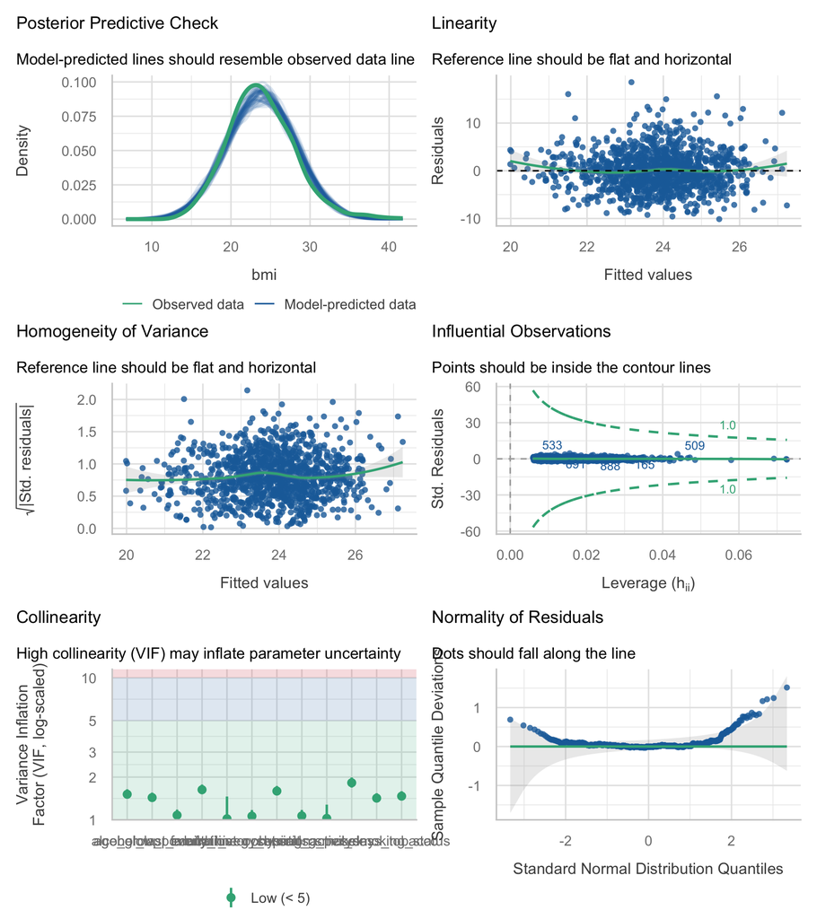

HC3 standard errors, shown for completeness

Heteroscedasticity was NOT flagged for this model

| Term | Estimate | SE (OLS) | SE (HC3) | p (OLS) | p (HC3) |
| --- | --- | --- | --- | --- | --- |
| sexMale | -0.560 | 0.357 | 0.342 | 0.1171 | 0.1015 |
| age_group60 or more | -1.099 | 0.385 | 0.390 | 0.0044 | 0.0050 |
| below_poverty_lineYes | -0.651 | 0.279 | 0.284 | 0.0199 | 0.0222 |
| smoking_statusCurrent | -1.013 | 0.375 | 0.386 | 0.0070 | 0.0087 |
| smokeless_tobaccoYes | -0.942 | 0.440 | 0.434 | 0.0323 | 0.0303 |
| family_history_htnYes | 1.348 | 0.342 | 0.378 | <0.001 | <0.001 |

# Discussion

Body mass index in these Bharatpur adults is barely predicted by the socio-demographic and behavioural variables collected in a STEPS survey. The associations that survive adjustment are all small and mostly point the way South Asian nutrition-transition literature would predict: people below the poverty line are lighter, not heavier (-0.65 kg/m2); tobacco users of both kinds are lighter; people in paid employment are heavier than those doing household work; and BMI declines in the oldest band. Family history of hypertension carries the largest single association at 1.35 kg/m2, consistent with shared familial and household determinants of cardiometabolic risk. Physical activity, salt, fruit and vegetables and education are all null. In practical terms, the message is that adiposity in this population is not readily explained by, or targeted through, the behaviours this instrument measures.

**Limitations.** The dominant limitation is the **weak model**: adjusted R-squared 0.064 means that essentially nothing here explains BMI, and the most important determinants – total energy intake, dietary composition beyond fruit and vegetable servings, sedentary time, parity and menopausal status in women, genetics – are simply not measured. Second, the **cluster sampling cannot be accounted for**: only four wards were randomly selected with around 300 participants each and a design effect of 1.5 assumed in the sample size calculation, but this extract contains no ward identifier, so all confidence intervals above are too narrow (plausibly by around 20%) and cannot be corrected. Estimates from four clusters cannot be generalised to Nepal or even to all of Bharatpur. Third, **age is available only in four bands**, so no per-year change in BMI can be estimated and the top band is open-ended. Fourth, this is cross-sectional, so the smoking and tobacco coefficients cannot be read causally: low body weight may lead to continued smoking as much as the reverse, and people who gain weight may quit. Fifth, `physical_activity` is a crude binary derived from a self-reported MET score with well-known over-reporting problems, which may explain its complete lack of association. Sixth, BMI itself does not distinguish fat from lean mass and performs poorly in South Asian populations, where cardiometabolic risk begins at lower BMI values – waist circumference would have been a better outcome but is not in this extract. On the credit side, **the file has no missing data at all** (all 1159 rows complete on all 21 variables), and height and weight were measured rather than self-reported, so the outcome itself is of good quality.

**Future work.** Repeat with waist circumference or waist-to-height ratio as the outcome, add dietary energy intake and sedentary time, and refit with the ward identifier as a random effect.

# Feasibility notes

*Not part of a student report.*